# p2_practice_mid_term_hes_e106

Gurdeep

21/10/2020

```r
rm(list = ls())

setwd("/cloud/project/practice_mid_term") # change to local directory before running

library(knitr)
library(onewaytests)
library(olsrr)
library(lmtest)
library(MASS)
library(ALSM)
y=c(98,135,162,178,221,232,283,300,374,395)
x=c(0,1,2,3,4,5,6,7,8,9)
```

2a-) is the linear fit appropriate? If not, transform the data and find an appropriate fit. Comment on the model and regression model assumptions. (20 points)

```r
reg2a <- lm(y~x)
summary(reg2a)
```

```
##
## Call:
## lm(formula = y ~ x)
##
## Residuals:
##     Min      1Q  Median      3Q     Max
## -22.049  -9.177   2.446   9.814  22.461
##
## Coefficients:
##             Estimate Std. Error t value Pr(>|t|)
## (Intercept)   91.564      8.814   10.39 6.38e-06 ***
## x             32.497      1.651   19.68 4.62e-08 ***
## ---
## Signif. codes:  0 '***' 0.001 '**' 0.01 '*' 0.05 '.' 0.1 ' ' 1
##
## Residual standard error: 15 on 8 degrees of freedom
## Multiple R-squared:  0.9798, Adjusted R-squared:  0.9772
## F-statistic: 387.4 on 1 and 8 DF,  p-value: 4.62e-08
```

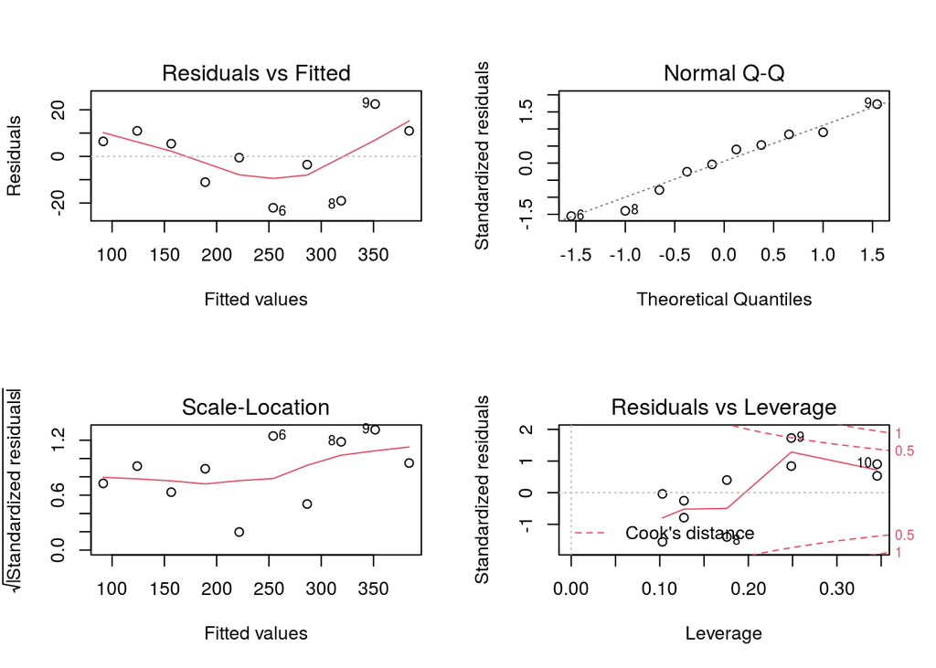

```r
ei_2a <- reg2a$residuals

# plot residuals and other standard plots
old.par <- par(mfrow = c(2,2))
plot(reg2a)
```

```r
old.par
```

```
## $mfrow
## [1] 1 1
```

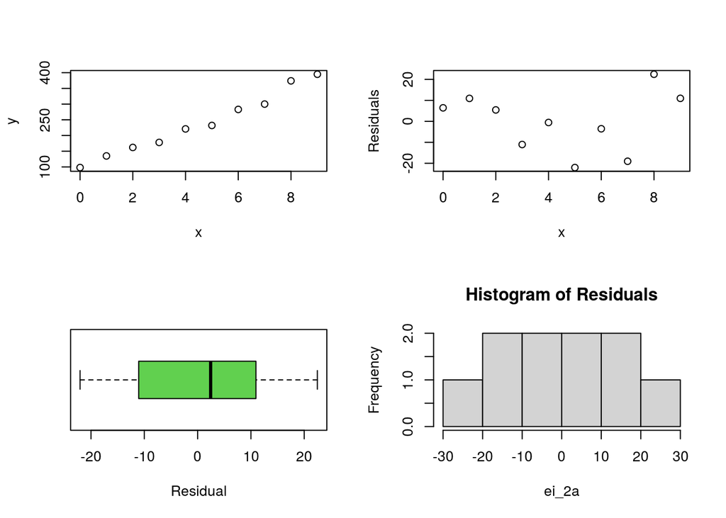

```r
newer.par = par(mfrow = c(2,2))
plot(x, y, xlab = 'x', ylab = 'y')
plot(x,ei_2a, xlab = 'x', ylab = 'Residuals')
boxplot(ei_2a, horizontal = TRUE, staplewax = 0.5, col = 3, xlab = 'Residual')
hist(ei_2a, main = 'Histogram of Residuals')
```

```r
newer.par
```

```
## $mfrow
## [1] 2 2
```

At 1st glance from the scatter plot we see what resembles a linear fit. Also we have high R2 (0.9798), high F-test, low p-values for F-test and both predictors, we see from both the residual vs fitted values plot and residuals vs x plots that the regression values have a pattern.

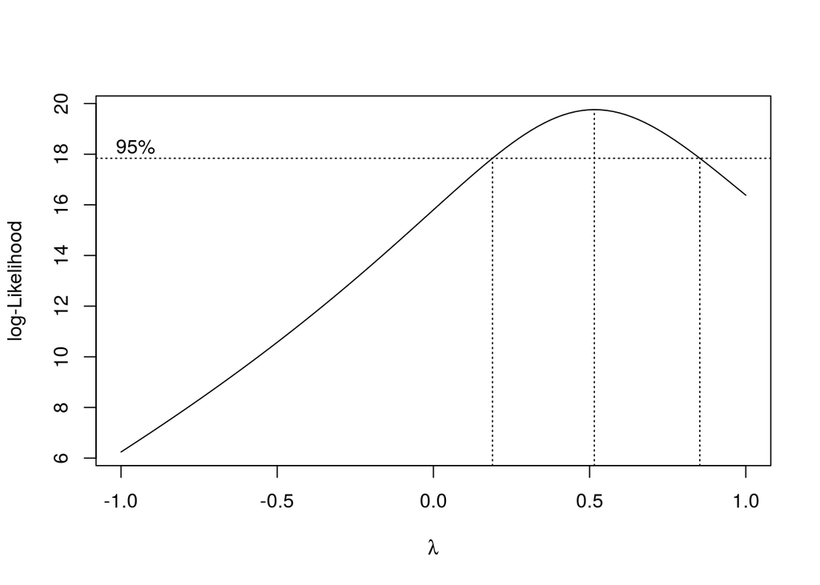

```r
boxcox(reg2a, lambda = seq(-1.0, 1.0,0.1))
```

From the boxcox test we see that recommended tranformation is of lambda = 0.5 i.e sqrt(Y). We perform the transformation and explore the results below

```r
reg2a_2 <- lm(sqrt(y)~x)
summary(reg2a_2)
```

```
##
## Call:
## lm(formula = sqrt(y) ~ x)
##
## Residuals:
##      Min       1Q   Median       3Q      Max
## -0.47447 -0.30811  0.01549  0.29541  0.46781
##
## Coefficients:
##             Estimate Std. Error t value Pr(>|t|)
## (Intercept) 10.26093    0.21290   48.20 3.80e-11 ***
## x            1.07629    0.03988   26.99 3.83e-09 ***
## ---
## Signif. codes:  0 '***' 0.001 '**' 0.01 '*' 0.05 '.' 0.1 ' ' 1
##
## Residual standard error: 0.3622 on 8 degrees of freedom
## Multiple R-squared:  0.9891, Adjusted R-squared:  0.9878
## F-statistic: 728.4 on 1 and 8 DF,  p-value: 3.826e-09
```

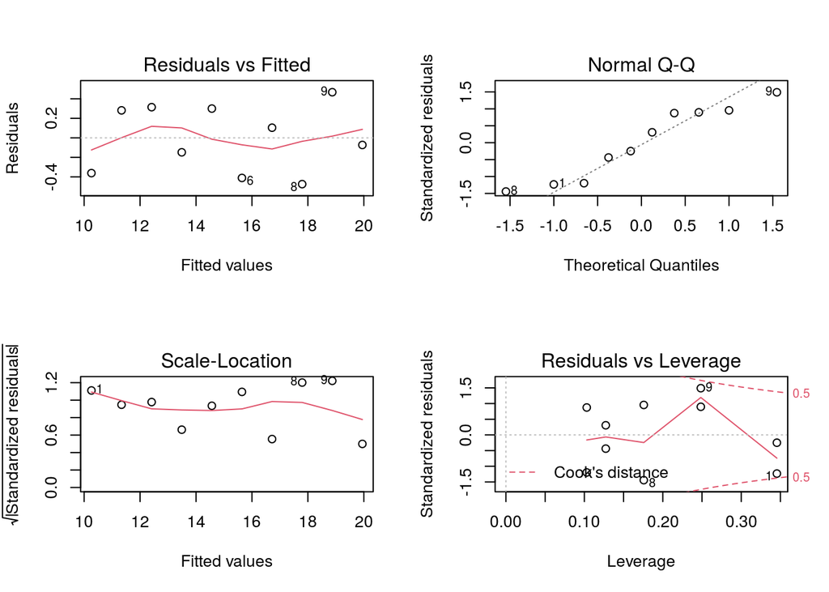

```r
ei_2a_2 <- reg2a_2$residuals

# plot residuals and other standard plots
old.par <- par(mfrow = c(2,2))
plot(reg2a_2)
```

```r
old.par
```

```
## $mfrow
## [1] 1 1
```

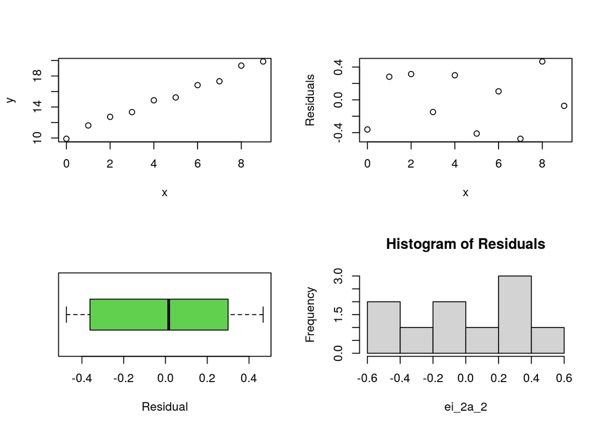

```r
newer.par = par(mfrow = c(2,2))
plot(x, sqrt(y), xlab = 'x', ylab = 'y')
plot(x,ei_2a_2, xlab = 'x', ylab = 'Residuals')
boxplot(ei_2a_2, horizontal = TRUE, staplewax = 0.5, col = 3, xlab = 'Residual')
hist(ei_2a_2, main = 'Histogram of Residuals')
```

```r
newer.par
```

```
## $mfrow
## [1] 2 2
```

From the above plots we see that the regression assumptions are now satisfied.

2b-) Predict Y when x=10, and calculate the prediction confidence interval for 90% confidence level (10 points)

```r
xh <- 10

pred <- predict(reg2a_2, data.frame(x = xh), level = 0.90, interval = 'prediction', se.fit = TRUE )
pred
```

```
## $fit
##        fit     lwr      upr
## 1 21.02385 20.2081 21.83959
##
## $se.fit
## [1] 0.2474483
##
## $df
## [1] 8
##
## $residual.scale
## [1] 0.3622272
```

```r
pred_val <- pred$fit^2
pred_val
```

```
##        fit      lwr      upr
## 1 442.0022 408.3675 476.9679
```

The final value of Y when x = 10 is 442.0022 with intervals between 408.3675 and 476.9679